# Figures + Tables

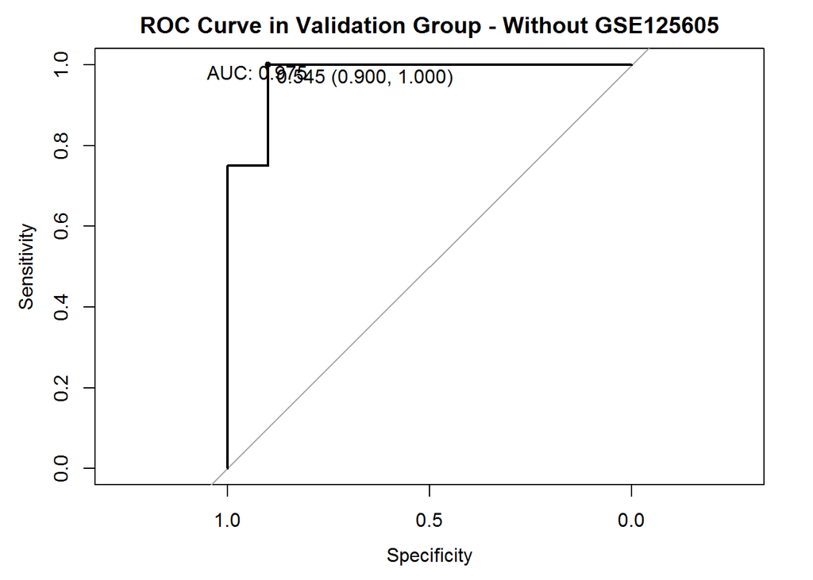

```r
# what does the ROC curve look like without GSE125605
metaVAL_noGSE125605 <- meta %>% filter(Group == "Validation") %>% filter(!GEO_Dataset == "GSE125605")  %>% mutate(Class_Binary = case_when(Class == "EOPE" ~ 1,
                                                                                                                                           Class == "Non-PE Preterm" ~ 0))

roc_obj_2 <- roc(metaVAL_noGSE125605$Class_Binary, metaVAL_noGSE125605$EOPE)
plot(roc_obj_2, print.thres="best", print.auc=TRUE, print.auc.x=1.05, print.auc.y=1, main="ROC Curve in Validation Group - Without GSE125605")
```

```r
coords(roc_obj_2, "best", "threshold")
```

```
##   threshold specificity sensitivity
## 1 0.5454187         0.9           1
```

The ideal threshold is suggested to be 0.5454187 according to the ROC curve, both when I look at it with and without GSE125605, which is the dataset that I am getting most misclassifications from. 15 out of the total 22 EOPE samples in GSE125605 were misclassified as nPTB. This suggests that ethnicity clearly has an effect on the predictor. Let’s create a column that classifies samples based on that threshold, and generate a plot of probabilities again.

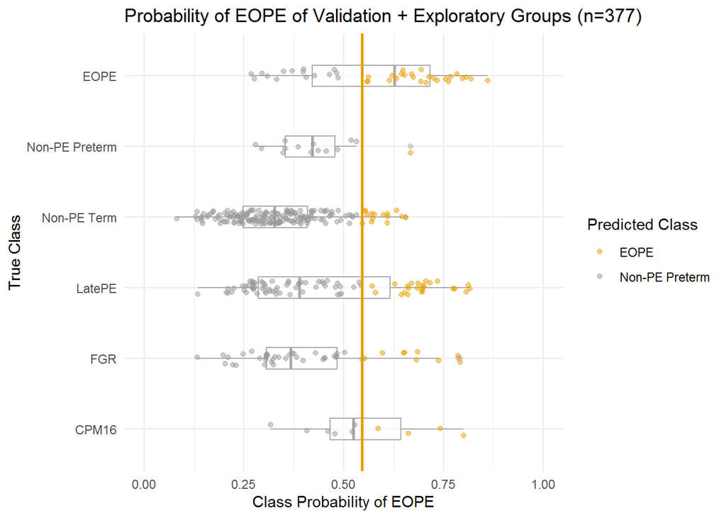

```r
meta <- meta %>% mutate(Pred_Class_Best = case_when(EOPE > 0.5454187 ~ "EOPE",
                                                    EOPE < 0.5454187 ~ "Non-PE Preterm"))

meta %>%
  mutate(True_Class = factor(Class,
                             levels=c("CPM16", "FGR", "LatePE", "Non-PE Term", "Non-PE Preterm", "EOPE"))) %>%
  ggplot() +
  geom_boxplot(aes(x = True_Class,
                  y = EOPE),
               width=0.3,
               alpha=0.5,
               color="darkgrey") +
  geom_jitter(aes(x = True_Class,
                  y = EOPE,
                  color = Pred_Class_Best),
              alpha = 0.5,
              position = position_jitter(width = .1)) +
  coord_flip() +
  ylab("Class Probability of EOPE") +
  xlab("True Class") +
  ylim(0,1) +
  scale_color_manual(name = "Predicted Class", values=c("#E69F00", "#999999")) +
  theme_minimal() +
  geom_hline(yintercept = 0.5454187,
             color = "#E69F00", size=1) +
  ggtitle("Probability of EOPE of Validation + Exploratory Groups (n=377)")
```

```r
ggsave(file="Figure3B.png",
       width=10, height=3.5,
       path = here::here("Output", "2022_Manuscript"),
       bg = "transparent",
       dpi=500)

tabyl(meta %>% filter(Class %in% c("EOPE", "Non-PE Preterm")), Class, Pred_Class_Best)
```

```
##           Class EOPE Non-PE Preterm
##            EOPE   25             15
##  Non-PE Preterm    1             13
```

Now, I want to look at ethnicity more closely.

```r
# plot average beta value at the 45 predictive CpGs in asian samples (>80%), african samples (>80%) and european samples (>80%)
predictors <- selectVar(mod)$name

dim(expPredictors <- exp[rownames(exp) %in% predictors,]) # 45
```

```
## [1]  45 328
```

```r
dim(valPredictors <- val[rownames(val) %in% predictors,]) # 45
```

```
## [1] 45 49
```

```r
dim(long_expPredictors <- as.data.frame.table(expPredictors))
```

```
## [1] 14760     3
```

```r
dim(long_valPredictors <- as.data.frame.table(valPredictors))
```

```
## [1] 2205    3
```

```r
dim(long_predictors <- rbind(long_expPredictors, long_valPredictors))
```

```
## [1] 16965     3
```

```r
head(long_predictors)
```

```
##         Var1       Var2      Freq
## 1 cg10246581 GSM1388230 0.6527898
## 2 cg09911083 GSM1388230 0.6301145
## 3 cg18584265 GSM1388230 0.6591328
## 4 cg12632411 GSM1388230 0.5669558
## 5 cg07913153 GSM1388230 0.3855307
## 6 cg10994126 GSM1388230 0.6079692
```

```r
long_predictors <- long_predictors %>% mutate(cpg = Var1, Sample_ID = Var2, beta = Freq) %>% dplyr::select(!c(Var1, Var2, Freq))
head(long_predictors)
```

```
##          cpg  Sample_ID      beta
## 1 cg10246581 GSM1388230 0.6527898
## 2 cg09911083 GSM1388230 0.6301145
## 3 cg18584265 GSM1388230 0.6591328
## 4 cg12632411 GSM1388230 0.5669558
## 5 cg07913153 GSM1388230 0.3855307
## 6 cg10994126 GSM1388230 0.6079692
```

```r
long_predictors <- left_join(long_predictors, meta, by="Sample_ID")
head(long_predictors)
```

```
##          cpg  Sample_ID      beta Subject_ID GEO_Dataset    Sex   Condition
## 1 cg10246581 GSM1388230 0.6527898       <NA>    GSE57767 Female Non-PE Term
## 2 cg09911083 GSM1388230 0.6301145       <NA>    GSE57767 Female Non-PE Term
## 3 cg18584265 GSM1388230 0.6591328       <NA>    GSE57767 Female Non-PE Term
## 4 cg12632411 GSM1388230 0.5669558       <NA>    GSE57767 Female Non-PE Term
## 5 cg07913153 GSM1388230 0.3855307       <NA>    GSE57767 Female Non-PE Term
## 6 cg10994126 GSM1388230 0.6079692       <NA>    GSE57767 Female Non-PE Term
##      IUGR Preterm Term PE GA   GA_RPC Ethnicity Maternal_Age Chip  Row Column
## 1 Unknown      No  Yes No NA 38.37877      <NA>           NA   NA <NA>   <NA>
## 2 Unknown      No  Yes No NA 38.37877      <NA>           NA   NA <NA>   <NA>
## 3 Unknown      No  Yes No NA 38.37877      <NA>           NA   NA <NA>   <NA>
## 4 Unknown      No  Yes No NA 38.37877      <NA>           NA   NA <NA>   <NA>
## 5 Unknown      No  Yes No NA 38.37877      <NA>           NA   NA <NA>   <NA>
## 6 Unknown      No  Yes No NA 38.37877      <NA>           NA   NA <NA>   <NA>
##   Predicted_ethnicity_nothresh Predicted_ethnicity Prob_African  Prob_Asian
```

[output cut: 34 more lines]

```r
# first, look at it just by class in the training set
all(colnames(train) == trainMeta$Sample_ID) # TRUE
```

```
## [1] TRUE
```

```r
dim(trainPredictors <- train[rownames(train) %in% predictors,]) # 45
```

```
## [1] 45 83
```

```r
dim(long_trainPredictors <- as.data.frame.table(trainPredictors) %>%
      mutate(cpg = Var1, Sample_ID = Var2, beta = Freq) %>% dplyr::select(!c(Var1, Var2, Freq)))
```

```
## [1] 3735    3
```

```r
head(long_trainPredictors)
```

```
##          cpg  Sample_ID      beta
## 1 cg10246581 GSM1388241 0.6296329
## 2 cg09911083 GSM1388241 0.6173375
## 3 cg18584265 GSM1388241 0.6721252
## 4 cg12632411 GSM1388241 0.4720250
## 5 cg07913153 GSM1388241 0.4104306
## 6 cg10994126 GSM1388241 0.6023959
```

```r
dim(long_trainPredictors <- left_join(long_trainPredictors, trainMeta, by="Sample_ID"))
```

```
## [1] 3735   34
```

```r
head(long_trainPredictors)
```

```
##          cpg  Sample_ID      beta          X Subject_ID GEO_Dataset  Sex
## 1 cg10246581 GSM1388241 0.6296329 GSM1388241       <NA>    GSE57767 Male
## 2 cg09911083 GSM1388241 0.6173375 GSM1388241       <NA>    GSE57767 Male
## 3 cg18584265 GSM1388241 0.6721252 GSM1388241       <NA>    GSE57767 Male
## 4 cg12632411 GSM1388241 0.4720250 GSM1388241       <NA>    GSE57767 Male
## 5 cg07913153 GSM1388241 0.4104306 GSM1388241       <NA>    GSE57767 Male
## 6 cg10994126 GSM1388241 0.6023959 GSM1388241       <NA>    GSE57767 Male
##        Condition    IUGR Preterm Term PE GA   GA_RPC Ethnicity Maternal_Age
## 1 Non-PE Preterm Unknown     Yes   No No NA 35.87492      <NA>           NA
## 2 Non-PE Preterm Unknown     Yes   No No NA 35.87492      <NA>           NA
## 3 Non-PE Preterm Unknown     Yes   No No NA 35.87492      <NA>           NA
## 4 Non-PE Preterm Unknown     Yes   No No NA 35.87492      <NA>           NA
## 5 Non-PE Preterm Unknown     Yes   No No NA 35.87492      <NA>           NA
## 6 Non-PE Preterm Unknown     Yes   No No NA 35.87492      <NA>           NA
##   Chip  Row Column Predicted_ethnicity_nothresh Predicted_ethnicity
```

[output cut: 27 more lines]

```r
tabyl(trainMeta, Class)
```

```
##           Class  n   percent
##            EOPE 42 0.5060241
##  Non-PE Preterm 41 0.4939759
```

```r
tabyl(trainMeta, Class, Predicted_ethnicity_nothresh)
```

```
##           Class African Asian Caucasian
##            EOPE       7     7        28
##  Non-PE Preterm       5     6        30
```

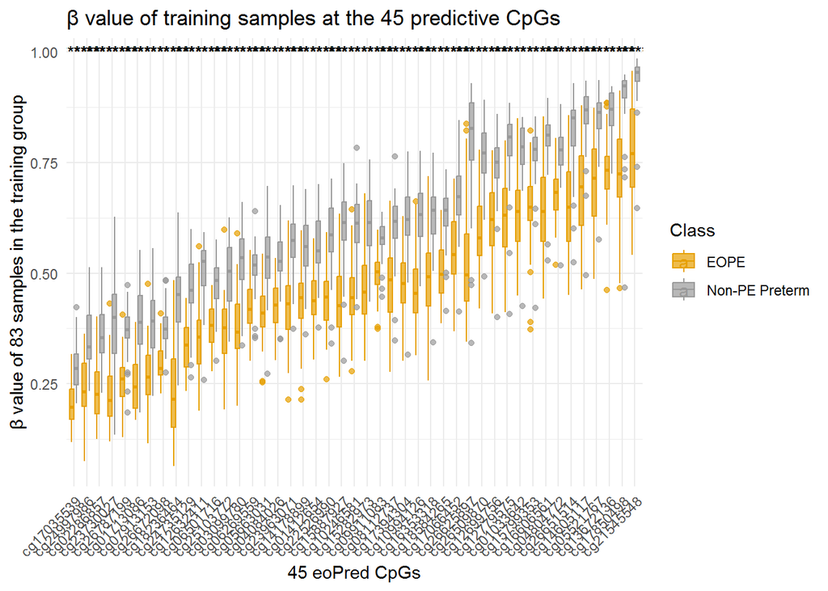

```r
long_trainPredictors %>%
  ggplot(aes(x=reorder(cpg, beta), y=beta, fill=Class, color=Class)) +
  geom_boxplot(alpha=0.7) +
  scale_fill_manual(name = "Class", values=c("#E69F00", "#999999")) +
  scale_color_manual(name = "Class", values=c("#E69F00", "#999999")) +
  theme_minimal() +
  xlab("45 eoPred CpGs") +
  ylab("\u03b2 value of 83 samples in the training group") +
  stat_compare_means(label="p.signif") +
  theme(axis.text.x = element_text(angle=45, hjust=1)) +
  ggtitle("\u03b2 value of training samples at the 45 predictive CpGs")
```

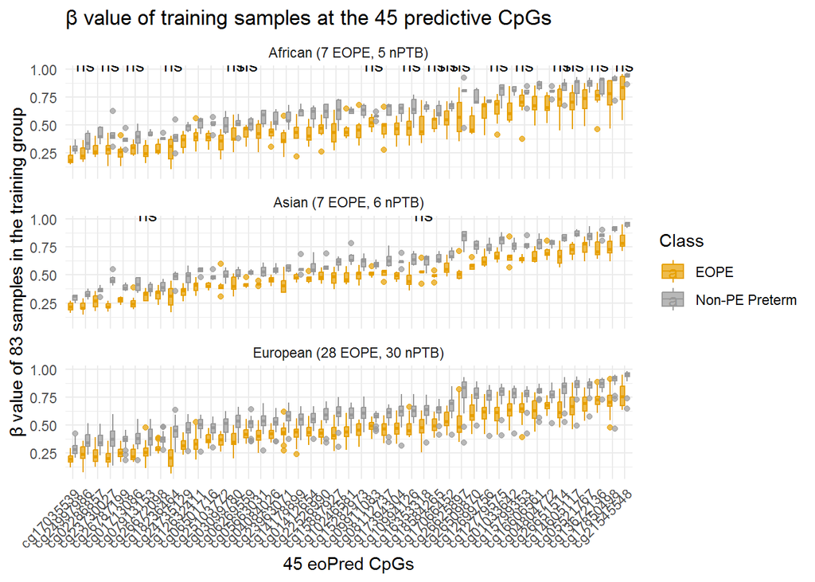

```r
ggsave(file="FigureSupp_TrainingBValues.png",
       width=17.5, height=3.5,
       path = here::here("Output", "2022_Manuscript"),
       bg = "transparent",
       dpi=500)

# now by ancestry
long_trainPredictors %>%
  mutate(Ancestry = case_when(Predicted_ethnicity_nothresh == "African" ~ "African (7 EOPE, 5 nPTB)",
                              Predicted_ethnicity_nothresh == "Asian" ~ "Asian (7 EOPE, 6 nPTB)",
                              Predicted_ethnicity_nothresh == "Caucasian" ~ "European (28 EOPE, 30 nPTB)")) %>%
  ggplot(aes(x=reorder(cpg, beta), y=beta, fill=Class, color=Class)) +
  geom_boxplot(alpha=0.7) +
  scale_fill_manual(name = "Class", values=c("#E69F00", "#999999")) +
  scale_color_manual(name = "Class", values=c("#E69F00", "#999999")) +
  theme_minimal() +
  facet_wrap(~Ancestry, ncol=1) +
  xlab("45 eoPred CpGs") +
  ylab("\u03b2 value of 83 samples in the training group") +
  stat_compare_means(label="p.signif") +
  theme(axis.text.x = element_text(angle=45, hjust=1)) +
  ggtitle("\u03b2 value of training samples at the 45 predictive CpGs")
```

```r
ggsave(file="FigureSupp_TrainingBValues_byAncestry.png",
       width=17.5, height=8,
       path = here::here("Output", "2022_Manuscript"),
       bg = "transparent",
       dpi=500)

# now in the validation
tabyl(as.data.frame(meta %>%
                      filter(Class %in% c("EOPE", "Non-PE Preterm")) %>%
                      filter(!is.na(Predicted_ethnicity_nothresh)) %>%
                      filter(Predicted_ethnicity_nothresh %in% c("Asian", "Caucasian"))),
      Predicted_ethnicity_nothresh, Class)
```

```
##  Predicted_ethnicity_nothresh EOPE Non-PE Preterm
##                         Asian   26              2
##                     Caucasian    9             12
```